# Your Plot Meta Analysis

Hi! I am you dataviz bot advisor_

I have looked into your plot and evaluated it against dataviz best practices and theoretical frameworks_

your plot looks **improvable**_

to be more precise your plot scored **0.26**

here it is a comparison between your score and the score obtained from plots included within the estimation database.

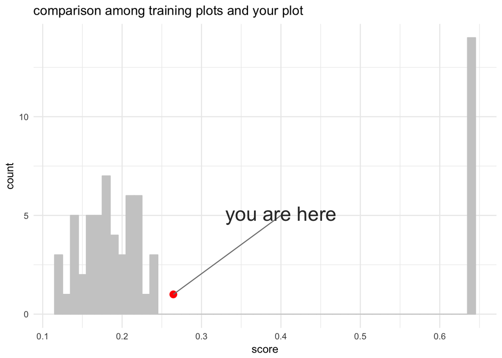

you can find more info about how my scoring algorithm works on my official webpage

let me tell you a bit more about this_

as far as I can see the data viz area in which your plot scored worst was the **adequateness of labeling**_

here it is a summary of your plot performance for each area.

| area_label | failed | passed | area_ratio |
| --- | --- | --- | --- |
| adequateness of labeling | 3 | 2 | 0.4 |
| data density | 1 | 1 | 0.5 |
| data to ink ratio | 1 | 1 | 0.5 |
| readability of the plot | 0 | 4 | 1.0 |

you can look into my documentation to learn which test were performed and how the scores were computed. you can also find more info about all on my official webpage

is now time to learn how to make your plot more effective applying dataviz principles_

I will give you an advice on how to fix your plot for each test failed_

**your plot is crowded due to overplotting**

you are incurring in **overplotting**: there are too many points to be displayed at once in an accurate way. you should consider introducing some faceting. If you rather want to maintain the current structure of the plot you could consider employing a different geom like `geom_bin2d()` able to better avoid overplotting_

**try to remove the grey background**

you are employing the default ggplot theme. while it is generally fit for its purpose you should consider removing that grey background, which lowers your data to ink ratio. Please find more info about data ink ratio on the [official info vis wiki page](https://infovis-wiki.net/wiki/Data-Ink_Ratio)_

**what is a book without a title?**

your plot is missing a title. this makes harder for your reader to understand its content. try to add a title employing `labs(title = ‘relevant title’)`_

**let us understand your plot better with a subtitle**

your plot is missing a subtitle. Subtitle are effective in providing additional relevant info about metrics and data showed in your plot.Try to add a plot employing labs(subtitle = ‘your subtitle’)_

**use caption to add integrity to your plot**

your plot is missing a caption. While not mandatories , captions are used to provide info about sources and reference period of your plot. This is crucial to increase the level of graphical integrity of your plot_

Hope you will find this useful and will help you improve your plot

Cheers,

*your dataviz bot advisor*